# Algorithm Class 6 - Lecture 3

Linked List

June/1/2019

# 1 Introduction

Array (continuously stored in the memory):

- byte[] a = {1, 2, 3, …} // 0xDEADBEEF

Linked List: does not have to be continuously stored.

## 1.1 Physical Memory of Linked List

| **0xFFFF0000** | **0xFFFF0001** | **0xFFFF0002** | **0xFFFF0003** | **0xFFFF0004** | **…** |
| --- | --- | --- | --- | --- | --- |
| a[0] ListNode1 ListNode next; // = 0xFFFF9999 | a[1] | a[2] ListNode3 next = null | … | … |  |
| **…** | **…** | **…** |  |  |  |
| **0xFFFF0005** | **0xFFFF0006** | **0xFFFF0007** | **0xFFFF0008** | **0xFFFF0009** | **…** |
|  |  |  |  | ListNode2 next = 0xFFFF0002 |  |

# 2 Basic Knowledge

```java
class ListNode {  // for ListNode 1, my own address 0xFFFF0001
  int value;  // = 1;
  string name;  // = "Node1"
  //...
  ListNode next;  // = 0xFFFF9999
}
```

```
N1 -> N2 -> N3 -> null;
```

Key points:

1. NPE error: when you want to dereference a ListNode, make sure it is not a NULL pointer

```java
ListNode p = new ListNode(10);
if (p == null || p.next == null) {
  return -1;
}
p.value;  // "." is an action that is called de-reference
p.next.value;
```

2. Never ever lose the control of the head pointer of the LinkedList

```
 N1 -> N2 -> N3 -> N4 -> null;
head
```

# 3 Problem 1: Reverse a Linked List

```
        N1 -> N2 -> N3 -> N4 -> ... -> NodeN -> NULL
       head

reversed:
NULL <- N1 <- N2 <- N3 <- N4 <- ... <- NodeN
                                        head
```

## 3.1 Solution 1: Iterative

```
null    N1 -> N2 -> N3 -> N4 -> ... -> NodeN -> NULL
prev   cur   next

---

null <- N1 -> N2 -> N3 -> N4 -> ... -> NodeN -> NULL
prev   cur   next

null <- N1 -> N2 -> N3 -> N4 -> ... -> NodeN -> NULL
       cur   next
      prev

null <- N1 -> N2 -> N3 -> N4 -> ... -> NodeN -> NULL
             next
      prev   cur

null <- N1 -> N2 -> N3 -> N4 -> ... -> NodeN -> NULL
      prev   cur   next
```

```java
// written by student
public ListNode reverseLinkedList(ListNode head) {
  ListNode prev = null;
  ListNode cur = head;

  while (cur != null) {
    ListNode next = cur.next;
    cur.next = prev;
    prev = cur;
    cur = next;
  }
  return prev;
}
```

```java
public ListNode reverseLinkedList(ListNode head) {
  ListNode prev = null;
  while (head != null) {
    ListNode next = head.next;
    head.next = prev;
    prev = head;
    head = next;
  }
  return prev;
}
```

- Time: O($n$)
- Space: O($1$)

## 3.2 Solution 2: Recursive

```
Before:
N1 -> [N2 -> N3 -> N4 -> ... -> NodeN -> NULL]

Magic:
N1 -> [N2 <- N3 <- N4 <- ... <- NodeN]

After:
1. N1 <-> [N2 <- N3 <- N4 <- ... <- NodeN]
2. NULL <- N1 <- [N2 <- N3 <- N4 <- ... <- NodeN]
```

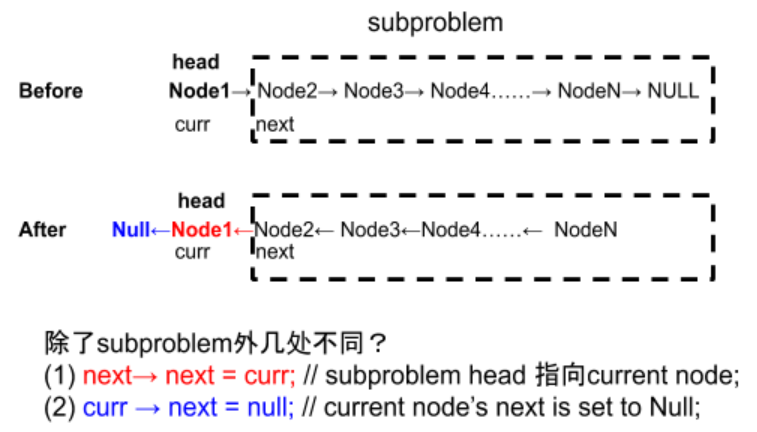

```
// written by student
public ListNode reverse(ListNode head) {
  if (head == null) {
    return null;
  }
  if (head.next == null) {
    return head;
  }
  ListNode newHead = reverse(head.next);
  head.next.next = head;
  head.next = null;
  return newHead;
}
```

```java
public ListNode reverse(ListNode head) {
  if (head == null || head.next == null) {
    return head;
  }
  ListNode newHead = reverse(head.next);  // breaking point
  head.next.next = head;
  head.next = null;
  return newHead;
}
```

- Time: O($n$)
- Space: O($n$)

Demo:

```
N1 -> N2 -> N3 -> NULL

1st call reverse:
 N1 -> N2 -> N3 -> NULL
head

2nd call reverse:
 N1 -> N2 -> N3 -> NULL
      head

3rd call reverse:
 N1 -> N2 -> N3 -> NULL
            head
now, newHead = N3, return to 2nd

---

Back to 2nd call reverse:
 N1 -> N2 -> N3 -> NULL
      head  newH

 N1 -> N2 <-> N3
      head  newH

      null
       ^
 N1 -> N2 <- N3
      head  newH

      null
       ^
 N1 -> N2 <- N3
head        newH

now, return to 1st

---

1. head.next.next = head (斷掉N2->Null,連接N2->N1)
 N1 <-> N2 <- N3
head         newH

2. head.next = null (斷掉N1->N2,連接N1->Null)
null
 ^
 N1 <- N2 <- N3
head        newH
```

# 4 Problem 2: Find the Middle Node of a Linked List

```
Step 0:
 N1 -> N2 -> N3 -> N4 -> N5 -> N6 -> NULL
slow
fast

---

Step 1:
 N1 -> N2 -> N3 -> N4 -> N5 -> N6 -> NULL
      slow
            fast

---

Step 2:
 0     1     2     3     4     5
 N1 -> N2 -> N3 -> N4 -> N5 -> N6 -> NULL
            slow
                        fast
```

1. Why not go through the linked list once and count the total number, then re-go through half way?
   - online algorithm v.s. offline algorithm
2. while loop termination condition:
   - fast.next != null && fast.next.next != null

# 5 Problem 3: Check whether a Linked List has a Ring

```
Step 0:
 N1 -> N2 -> N3 -> N4 -> N5 -> N6
                    <-----------
slow
fast

---

Step 1:
 N1 -> N2 -> N3 -> N4 -> N5 -> N6
                    <-----------
      slow
            fast

---

Step 2:
 N1 -> N2 -> N3 -> N4 -> N5 -> N6
                    <-----------
            slow
                        fast

---

Step 3:
 N1 -> N2 -> N3 -> N4 -> N5 -> N6
                    <-----------
                  slow
                  fast
```

1. while loop termination condition:
   - fast == slow

# 6 Problem 4: Insert a Node in a Sorted Linked List

```
 1 -> 3 -> 6 -> 9 -> null
cur  next

target == 7 or 0 or 10
```

- Case 1: head == null || target <= head.value
  - Insert before the head

```
Left Condition:

Step 0:
null
target == 7

---

Step 1:
7 -> null
```

```
Right Condition:

Step 0:
1 -> 3 -> 6 -> 9 -> null
target == 0

---

Step 1:
0 -> 1 -> 3 -> 6 -> 9 -> null
```

- Case 2: cur.next == null || cur.next.value >= target
  - Insert to the following place

```
Left Condition: (the target is larger than the largest number in the list)

Step x:
1 -> 3 -> 6 -> 9 -> null
              cur   next
target == 10

---

Step x+1:
1 -> 3 -> 6 -> 9 -> 10 -> null
```

```
Right Condition: (the target is less or equal to the next number, so insert the target between current pointer and next pointer)

Step x:
1 -> 3 -> 6 -> 9 -> null
         cur  next
target == 7

---

Step x+1:
1 -> 3 -> 6 -> 7 -> 9 -> null
```

**舉一反三**: Insert a node in a circular linked list

# 7 Problem 5: Merge two Sorted Linked Lists

```
Given:
1 -> 3 -> 5 -> null
2 -> 4 -> 6 -> null

Result:
1 -> 2 -> 3 -> 4 -> 5 -> 6 -> null
```

```
Step 0:
 1 -> 3 -> 5 -> null
cur1
 2 -> 4 -> 6 -> null
cur2
dummyHead ->
```

- 誰小移誰

# 8 Discussion

1. What is DummyHead? When to use it?
   - When we want to build a LinkedList from scratch (initially zero node). In order to avoid null pointer dereference, we need to use a dummy head.

```java
ListNode dummyNode = new ListNode();
dummyNode.next = N1;
dummyNode = dummyNode.next;
```

2. When should we maintain a tail pointer, besides the header?
   - When we want to append a new Node to the end of the LinkedList.

# 9 Problem 6: 首尾連接

```
Given:
N1 -> N2 -> N3 -> N4 -> ... -> Nn-3 -> Nn-2 -> Nn-1 -> Nn -> null

Result:
N1 -> Nn -> N2 -> Nn-1 -> N3 -> Nn-2 -> N4 -> Nn-3 -> ... -> null
```

Solution:

- Step 1 (Problem 2)
  - Find the middle node of the linked list and split it into two halves.
- Step 2 (Problem 1)
  - Reverse the 2-nd half of the linked list
- Step 3 (Problem 5 Variant)
  - Merge two linked lists

# 10 Problem 7: Partition List

Given a linked list and a target value x, partition it such that all nodes less than x are listed before the nodes larger than or equal to target value x. Keep the original relative order of the nodes in each of the two partitions.

```
Input: 1 -> 6 -> 3 -> 2a -> 5 -> 2b -> null
target x = 4

Output: 1 -> 3 -> 2a -> 2b -> 6 -> 5 -> null
```

**Solution:**

Step 1: Allocate two new linked list heads (one for small values, one for large values).

```
dummySmallHead ->
dummyLargeHead ->
```

Step 2: Iterate over every single element in the list, and compare the current node’s value with the target’s value:

- Case 1: if current.value < target.value
  - Add the current node to the tail of the first linked list.
- Case 2: if current.value >= target.value
  - Add the current node to the tail of the second linked list.

```
dummySmallHead -> 1 -> 3 -> 2a -> 2b -> null
dummyLargeHead -> 6 -> 5 -> (2b)
```

Step 3: Concatenate the tail of the first half to the head of the 2-nd linked list.

```java
smallTail.next = dummyLargeHead.next;
```

```
dummySmallHead -> 1 -> 3 -> 2a -> 2b -> 6 -> 5
                                   <---------
```

Step 4: Clear the tail of the (large) list to NULL, return dummySmallHead.next

```
dummySmallHead -> 1 -> 3 -> 2a -> 2b -> 6 -> 5 -> null
```

**Code:**

```java
public class PartitionLinkedList {
  public ListNode partition(ListNode head, int x) {
    if (head == null) {
      return null;
    }
    ListNode fakeHeadSmall = new ListNode(0);
    ListNode fakeHeadLarge = new ListNode(0);
    ListNode smallTail = fakeHeadSmall;
    ListNode largeTail = fakeHeadLarge;
    ListNode current = head;
    while (current != null) {
      if (current.val < x) {
        smallTail.next = current;
        smallTail = current;
      }
      else {
        largeTail.next = current;
        largeTail = current;
      }
      current = current.next;
    }
    largeTail.next = null;  // terminate the list with null
    smallTail.next = fakeHeadLarge.next;
    return fakeHeadSmall.next;
  }
}
```

# 11 Problem 8: MergeSort Linked List

```
Input: 4 -> 2 -> 6 -> -3 -> 5 -> null

Output: -3 -> 2 -> 4 -> 5 -> 6 -> null
```

- Step 1 (Question 2: `findMiddle(head)`)
  - Split the list into two halves
- Step 2 (Recursion)
  - Sort each half
- Step 3 (Question 5: `merge(left, right)`)
  - Combine two halves

```
public ListNode mergeSort(ListNode head) {
  // Base case
  if (head == null || head.next == null) {
    return head;
  }

  // Step 1


  // Step 2


  // Step 3

}
```

- Total time = O($n\log(n)+n\log(n)$)=O($n\log(n)$)
- Space = O($\log(n)$)

# 12 Problem 9: Add Two Numbers

You are given two linked lists representing two non-negative numbers. **The digits are stored in reverse order** and each of their nodes contain a single digit. Add the two numbers and return it as a linked list.

```
341 + 465 = 806

Input:  1 -> 4 -> 3 -> null (341)
        5 -> 6 -> 4 -> null (465)
Output: 6 -> 0 -> 8 -> null (806)
```

- Idea: do the “merge” operation one by one, mind the carry when doing the addition.

**Follow Up: Add Two Numbers II**

The digits are stored in normal order.

```
Input:  1 -> 4 -> 3 -> null (143)
        5 -> 6 -> 4 -> null (564)
Output: 7 -> 0 -> 7 -> null (707)
```

- Idea: reverse the two input linked list first.

# 13 Problem 10: Check whether a Linked List is a Palindrome

Space complexity must be O($1$)

```
Input:  1 -> 2 -> 3 -> 2 -> 1 -> null
Output: true

Input:  1 -> 2 -> 3 -> null
Output: false
```

# 14 Problem 11: Remove All Nodes with Target Value

```
Input:  2 -> 3 -> 6 -> 4 -> 6 -> null, target == 6
Output: 2 -> 3 -> 4 -> null
```

- Idea: Use a dummyHead, because the actual head may be changed.

# 15 Discussion

When to use iterative way v.s. recursive way

1. In real work environment, consider using iterative way first to avoid call stack overflow.
2. In interview environment
   1. for tree related problem, usually using recursive way is more preferred.
   2. for other problem, you can evaluate the real problem
      1. if you can use both methods and their time complexities are the same, then you can use either way.
      2. if their time complexities are different, of course you should pick the one with smaller time complexity.